# Analyzing the Indian Premier League

### a tutorial by Hiteesh Nukalapati

## Introduction

What is the Indian Premier League(IPL)?  
It is the world's most popular, most watched, most sought-after cricket league.  
What is Criket?  
Criket is 11 member team sport consisting of batters and bowlers. It can be played in a stadium of any shape and size as long as the center has 22-yard rectangular box called the pitch. There are two innings(phases) in a match and the team that wins the toss, get to pick what they want to do first (i.e bat first or bowl first). So the bowlers bowl to the batter and A batter scores by hitting the ball to get runs whereas the bowler aims to get wickets (i.e. the batter out). There are multiple formats of the game but the IPL follows the T20 format which stands for 20-20 which simply means that each team get to bowl 20 overs (each over consists of 6 balls, which means every innings has a maximum of 120 balls). A team can win the match in two main ways:

- Chase the target set by the team batting first (in terms of runs)
- Get all the batters of the team batting second out before they chase down the total (in terms of wickets, need to take 10)

This is all the information you will need to understand and follow the tutorial but I encourage you to learn more about the game at https://en.wikipedia.org/wiki/Cricket. It is a beautiful game!  
So why did I choose the IPL to create a tutorial?  
It simply reminds my of India, cricket is a big sport in India and I care about it deeply. This seasons IPL was posponed indefinitely due to the raging COVID-19 Pandemic that has taken the country by storm. I planned on going to India this summer and looks like that is not happening. So i though what if I try to better understand the game, maybe along the way I will find some interesting facts about it and I will also miss the game a little less (Win-Win!!)

## Set up

```python
import numpy as np # linear algebra
import pandas as pd # data processing

#used for plotting
import matplotlib.pyplot as mlt
mlt.style.use('fivethirtyeight')
import seaborn as sns

# Used for interactive graphs
import plotly.offline as py
import plotly.graph_objs as go
import plotly.tools as tls
```

## Locating and Loading the data

After a bit of googling, I found a data set that contains ball-by-ball data for IPL matches between 2008 and 2016 on kaagle: https://www.kaggle.com/manasgarg/ipl  
This dataset consists of two CSV's (Common format of sharing data, stands for Comma Separated Value):

- deliveries.csv (contains ball-by-ball data for every match with unique match_id)
- matches.csv (contains match details such as location, teams, umpires etc.)

I will load both these files into two separate Pandas Dataframes. There is an inbuilt library function called `read_csv()`. This function simply takes the path to the file and converts it to a DataFrame (which is a 2D data structure used to store data, like a SQL table).

```python
matches = pd.read_csv('matches.csv')
deliveries = pd.read_csv('deliveries.csv')
```

```python
matches.head()
```

|  | id | season | city | date | team1 | team2 | toss_winner | toss_decision | result | dl_applied | winner | win_by_runs | win_by_wickets | player_of_match | venue | umpire1 | umpire2 | umpire3 |
| --- | --- | --- | --- | --- | --- | --- | --- | --- | --- | --- | --- | --- | --- | --- | --- | --- | --- | --- |
| 0 | 1 | 2017 | Hyderabad | 2017-04-05 | Sunrisers Hyderabad | Royal Challengers Bangalore | Royal Challengers Bangalore | field | normal | 0 | Sunrisers Hyderabad | 35 | 0 | Yuvraj Singh | Rajiv Gandhi International Stadium, Uppal | AY Dandekar | NJ Llong | NaN |
| 1 | 2 | 2017 | Pune | 2017-04-06 | Mumbai Indians | Rising Pune Supergiant | Rising Pune Supergiant | field | normal | 0 | Rising Pune Supergiant | 0 | 7 | SPD Smith | Maharashtra Cricket Association Stadium | A Nand Kishore | S Ravi | NaN |
| 2 | 3 | 2017 | Rajkot | 2017-04-07 | Gujarat Lions | Kolkata Knight Riders | Kolkata Knight Riders | field | normal | 0 | Kolkata Knight Riders | 0 | 10 | CA Lynn | Saurashtra Cricket Association Stadium | Nitin Menon | CK Nandan | NaN |
| 3 | 4 | 2017 | Indore | 2017-04-08 | Rising Pune Supergiant | Kings XI Punjab | Kings XI Punjab | field | normal | 0 | Kings XI Punjab | 0 | 6 | GJ Maxwell | Holkar Cricket Stadium | AK Chaudhary | C Shamshuddin | NaN |
| 4 | 5 | 2017 | Bangalore | 2017-04-08 | Royal Challengers Bangalore | Delhi Daredevils | Royal Challengers Bangalore | bat | normal | 0 | Royal Challengers Bangalore | 15 | 0 | KM Jadhav | M Chinnaswamy Stadium | NaN | NaN | NaN |

```python
matches['umpire3'].unique()
```

```
array([nan])
```

```python
deliveries.head()
```

|  | match_id | inning | batting_team | bowling_team | over | ball | batsman | non_striker | bowler | is_super_over | ... | bye_runs | legbye_runs | noball_runs | penalty_runs | batsman_runs | extra_runs | total_runs | player_dismissed | dismissal_kind | fielder |
| --- | --- | --- | --- | --- | --- | --- | --- | --- | --- | --- | --- | --- | --- | --- | --- | --- | --- | --- | --- | --- | --- |
| 0 | 1 | 1 | Sunrisers Hyderabad | Royal Challengers Bangalore | 1 | 1 | DA Warner | S Dhawan | TS Mills | 0 | ... | 0 | 0 | 0 | 0 | 0 | 0 | 0 | NaN | NaN | NaN |
| 1 | 1 | 1 | Sunrisers Hyderabad | Royal Challengers Bangalore | 1 | 2 | DA Warner | S Dhawan | TS Mills | 0 | ... | 0 | 0 | 0 | 0 | 0 | 0 | 0 | NaN | NaN | NaN |
| 2 | 1 | 1 | Sunrisers Hyderabad | Royal Challengers Bangalore | 1 | 3 | DA Warner | S Dhawan | TS Mills | 0 | ... | 0 | 0 | 0 | 0 | 4 | 0 | 4 | NaN | NaN | NaN |
| 3 | 1 | 1 | Sunrisers Hyderabad | Royal Challengers Bangalore | 1 | 4 | DA Warner | S Dhawan | TS Mills | 0 | ... | 0 | 0 | 0 | 0 | 0 | 0 | 0 | NaN | NaN | NaN |
| 4 | 1 | 1 | Sunrisers Hyderabad | Royal Challengers Bangalore | 1 | 5 | DA Warner | S Dhawan | TS Mills | 0 | ... | 0 | 0 | 0 | 0 | 0 | 2 | 2 | NaN | NaN | NaN |

5 rows × 21 columns

```python
matches['team1'].unique()
```

```
array(['Sunrisers Hyderabad', 'Mumbai Indians', 'Gujarat Lions',
       'Rising Pune Supergiant', 'Royal Challengers Bangalore',
       'Kolkata Knight Riders', 'Delhi Daredevils', 'Kings XI Punjab',
       'Chennai Super Kings', 'Rajasthan Royals', 'Deccan Chargers',
       'Kochi Tuskers Kerala', 'Pune Warriors', 'Rising Pune Supergiants'],
      dtype=object)
```

## Tidying the data

When we look at the data, we realize that in the matches table(DataFrame), the `umpire3` column is empty, filled with NaN's. So we can go ahead and and drop that column from our table.  
When we look at the deliveries table, we see that a few entries in columns are NaN's.  
Now, we must not drop these column (because they indicate something important when they actually contain a value) but we must make these columns useful and usable to ourselves. To do this, I will replace all `NaN` values in the deliveries table with `0`'s.  
Doing this in this situation is very useful as we are not missing data, instead here, NaN's are used to indicate that the specific event did not occur. For this data, this is the best way to go forward but this might not always be the best choice, it always will depend on the type of data and analysis we want to perform.  
The team Rising Pune Supergiants cahnged their name to remove the trailing s, I make sure that this is also accounted for by renaming them to RPS.  
For further simplicity I am going to abbreviate team names so that it is easier for us to type, display and utilize the same. We got all the unique teams in the data by running `matches['team1'].unique()`

```python
# Dropping the umpire3 Column
matches.drop(['umpire3'],axis=1,inplace=True)

#Filling values in the delivery table with 0's
deliveries.fillna(0,inplace=True)

#Replacing the Team Names with their abbreviations
matches.replace(['Mumbai Indians','Kolkata Knight Riders','Royal Challengers Bangalore','Deccan Chargers','Chennai Super Kings',
                 'Rajasthan Royals','Delhi Daredevils','Gujarat Lions','Kings XI Punjab',
                 'Sunrisers Hyderabad','Rising Pune Supergiants','Kochi Tuskers Kerala','Pune Warriors','Rising Pune Supergiant']
                ,['MI','KKR','RCB','DC','CSK','RR','DD','GL','KXIP','SRH','RPS','KTK','PW','RPS'],inplace=True)

deliveries.replace(['Mumbai Indians','Kolkata Knight Riders','Royal Challengers Bangalore','Deccan Chargers','Chennai Super Kings',
                 'Rajasthan Royals','Delhi Daredevils','Gujarat Lions','Kings XI Punjab',
                 'Sunrisers Hyderabad','Rising Pune Supergiants','Kochi Tuskers Kerala','Pune Warriors','Rising Pune Supergiant']
                ,['MI','KKR','RCB','DC','CSK','RR','DD','GL','KXIP','SRH','RPS','KTK','PW','RPS'],inplace=True)
```

## Basic Analysis

```python
print('Total Matches Played:',matches.shape[0])
print('Total venues played at:',matches['city'].nunique())
print(' \n Venues Played At:',matches['city'].unique())
print(' \n Teams :',matches['team1'].unique())
print('MVP:',(matches['player_of_match'].value_counts()).idxmax())
print('Team with most wins:',((matches['winner']).value_counts()).idxmax())
```

```
Total Matches Played: 636
Total venues played at: 30

 Venues Played At: ['Hyderabad' 'Pune' 'Rajkot' 'Indore' 'Bangalore' 'Mumbai' 'Kolkata'
 'Delhi' 'Chandigarh' 'Kanpur' 'Jaipur' 'Chennai' 'Cape Town'
 'Port Elizabeth' 'Durban' 'Centurion' 'East London' 'Johannesburg'
 'Kimberley' 'Bloemfontein' 'Ahmedabad' 'Cuttack' 'Nagpur' 'Dharamsala'
 'Kochi' 'Visakhapatnam' 'Raipur' 'Ranchi' 'Abu Dhabi' 'Sharjah' nan]

 Teams : ['SRH' 'MI' 'GL' 'RPS' 'RCB' 'KKR' 'DD' 'KXIP' 'CSK' 'RR' 'DC' 'KTK' 'PW']
MVP: CH Gayle
Team with most wins: MI
```

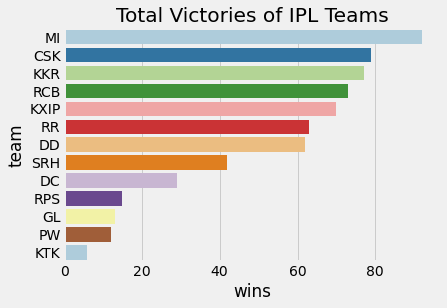

```python
# Lets Calculate and plot the number of wins by each team across seasons!
team_wins = matches['winner'].value_counts()

team_wins_df = pd.DataFrame(columns=["team", "wins"])
for items in team_wins.iteritems():
    temp_df1 = pd.DataFrame({
        'team':[items[0]],
        'wins':[items[1]]
    })
    team_wins_df = team_wins_df.append(temp_df1, ignore_index=True)

mlt.title("Total Victories of IPL Teams")
sns.barplot(x='wins', y='team', data=team_wins_df, palette='Paired');
```

As we can see, MI (Mumbai Indians) is the most successful IPL team, infact they've the tournamnet 5 times now!  
As we can see, visualization is an important aspect of data analysis, it lets us put things in perspective. Here, we used the matplotlib and seaborn libraries to plot the above graph. We created a barplot with using the seaborn library `barplot` function. We always have to send data to a visualization function and sending the right data is very important. So, above, we created a new dataframe called team_wins_df that holds the exact data we need to plot the above graph.

## Further Analysis and Visualization

In the game of cricket, toss is a very important factor. Cricket gives the team winning the toss an edge, because they get their preffered decision (to either bowl first or bat first) this decision is made by the captain and coach after taking into considerations like ground size, due(mist) factor, opposition, time of the day etc.  
Lets take a closer look at Toss, Toss Decisions and the way it affects the game

```python
print('Toss Decisions in %:\n',((matches['toss_decision']).value_counts())/matches.shape[0]*100)
```

```
Toss Decisions in %:
 field    57.075472
bat      42.924528
Name: toss_decision, dtype: float64
```

We use `matches.shape[0]` to get the total number of matches and we use `matches['toss_decision'].value_counts()` to count the occurence of each event.  
As we can see 57% of the teams winning the toss decide to Field (Bowl) first and the rest chose to Bat first

### Lets look at the Toss decisions across seasons:

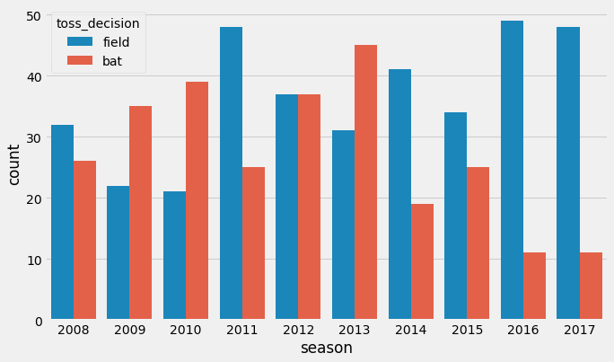

```python
# using a countplot to show toss decisions.
mlt.subplots(figsize=(10,6))
sns.countplot(x='season',hue='toss_decision',data=matches)
mlt.show()
```

2016 was the year there was the hishest divide between teams choosing to feild first vs those chosing to bat first while 2012 was the season with the lowest divide  
Unsrprisingly, across years, there is a lot of variation as to how teams choose a decision at a toss. This is can be because of the location the teams were playing: Some conditions call for feilding first while others call for batting first.  
Lets see where the 2012 and 2017 season were played.

```python
matches[matches.season == 2012].head(3)
```

|  | id | season | city | date | team1 | team2 | toss_winner | toss_decision | result | dl_applied | winner | win_by_runs | win_by_wickets | player_of_match | venue | umpire1 | umpire2 |
| --- | --- | --- | --- | --- | --- | --- | --- | --- | --- | --- | --- | --- | --- | --- | --- | --- | --- |
| 307 | 308 | 2012 | Chennai | 2012-04-04 | CSK | MI | MI | field | normal | 0 | MI | 0 | 8 | RE Levi | MA Chidambaram Stadium, Chepauk | JD Cloete | SJA Taufel |
| 308 | 309 | 2012 | Kolkata | 2012-04-05 | KKR | DD | DD | field | normal | 0 | DD | 0 | 8 | IK Pathan | Eden Gardens | S Asnani | HDPK Dharmasena |
| 309 | 310 | 2012 | Mumbai | 2012-04-06 | PW | MI | MI | field | normal | 0 | PW | 28 | 0 | SPD Smith | Wankhede Stadium | AK Chaudhary | SJA Taufel |

```python
matches[matches.season == 2017].head(3)
```

|  | id | season | city | date | team1 | team2 | toss_winner | toss_decision | result | dl_applied | winner | win_by_runs | win_by_wickets | player_of_match | venue | umpire1 | umpire2 |
| --- | --- | --- | --- | --- | --- | --- | --- | --- | --- | --- | --- | --- | --- | --- | --- | --- | --- |
| 0 | 1 | 2017 | Hyderabad | 2017-04-05 | SRH | RCB | RCB | field | normal | 0 | SRH | 35 | 0 | Yuvraj Singh | Rajiv Gandhi International Stadium, Uppal | AY Dandekar | NJ Llong |
| 1 | 2 | 2017 | Pune | 2017-04-06 | MI | RPS | RPS | field | normal | 0 | RPS | 0 | 7 | SPD Smith | Maharashtra Cricket Association Stadium | A Nand Kishore | S Ravi |
| 2 | 3 | 2017 | Rajkot | 2017-04-07 | GL | KKR | KKR | field | normal | 0 | KKR | 0 | 10 | CA Lynn | Saurashtra Cricket Association Stadium | Nitin Menon | CK Nandan |

Turns out, both the 2012 season and 2017 season were played in India! So it might not be the location then. It could just be a shift in strategy by coaches and teams

## Lets look at the teams that won the most number of tosses:

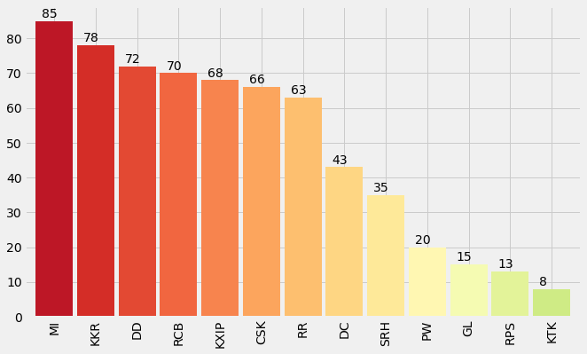

```python
# Creating a plot that will contain the teams that won the most tosses
mlt.subplots(figsize=(10,6))
ax=matches['toss_winner'].value_counts().plot.bar(width=0.9,color=sns.color_palette('RdYlGn',20))
for p in ax.patches:
    ax.annotate(format(p.get_height()), (p.get_x()+0.15, p.get_height()+1))
mlt.show()
```

As we can see, MI has won the most tosses! also this barplot is very similar to the barplot above labelled "Total Victories of IPL Teams". How is it similar? we can see that most of the teams that are successful are also good at winning tosses! (more precisely, lucky) So a toss can be an important factor in cricket. Please note, it is important to understand that this chart, in no way, indicates that MI and other teams winning a lot of tosses have a higher chance of winning the toss.  
That is the teams on the lower end GL, RPS, KTK do not have a bad chance at winning the toss, they just did not play enough games! This is a very important observation **(i.e.) This Data is not standardized.**

### Let's see if the toss winner is also the match winner

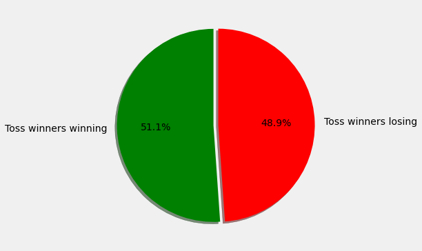

```python
# creating a temp df to store only the data we need.
df=matches[matches['toss_winner']==matches['winner']]
slices=[len(df),(636-len(df))]

# labels for the pie chart
labels=['Toss winners winning','Toss winners losing']

# creating a pie chart using matplotlib.pie
mlt.pie(slices,labels=labels,startangle=90,shadow=True,explode=(0,0.05),autopct='%1.1f%%',colors=['g','r'])
fig = mlt.gcf()
fig.set_size_inches(6,6)
mlt.show()
```

Important fact: The probability of winning the toss is equal for both the teams as a 2 sided coin is flipped at the toss.  
From the above pie chart, we see that winning the toss does not necessarily mean winning the match!  
At this point, It is also nice to appreciate the fact that we have all these inbuilt library functions that make our lives easy. All we have to do is filter data to a format that would suit the visualixation we choose.  
Above, we used the matplotlib `pie` method to create the pie chart.

### What about finals?

Lets see how the Toss and other factors impact the tournament decider!

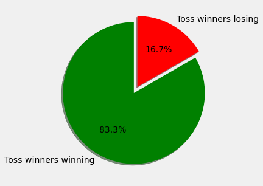

```python
# Creating a finals_df that contains only the last/final match of every season
finals_df=matches.drop_duplicates(subset=['season'],keep='last')
finals_df=finals_df[['id','season','city','team1','team2','toss_winner','toss_decision','winner']]

# creating a temp df to create a pie chart.
df=finals_df[finals_df['toss_winner']==finals_df['winner']]
slices=[len(finals_df),(9-len(df))]
labels=['Toss winners winning','Toss winners losing']

# creating the pie chart
mlt.pie(slices,labels=labels,startangle=90,shadow=True,colors=['g','r'],explode=(0,0.1),autopct='%1.1f%%')
fig = mlt.gcf()
fig.set_size_inches(5,5)
mlt.show()
```

#### Lets see How a decision after winning the toss affects the outcome of the game:

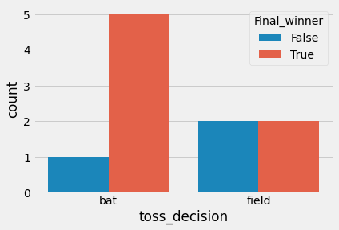

```python
# small and simple countplot to see the how the decision to field/bat affects
# the outcome of the tournament decider/final
finals_df['Final_winner']=finals_df['toss_winner']==finals_df['winner']
sns.countplot(x='toss_decision',hue='Final_winner',data=finals_df)
mlt.show()
```

Above, True=Winning/Won the game and False=Losing/Lost the game  
Looks like the team winning the toss choosing to Bat first has won the final the most times. Captains and coaches should definitely take this into consideration! while making a decison in the final!

## Now, lets look at a few interesting and important stats.

I will explain what the significance of each statistic is and how it affects the team.

#### Runs across seasons.

Batters are responsible for the runs each team scores.The more the runs, the harder it is for the team batting second to win the match, this also gives the team bowling second a good leeway to get the batters of the team batting second out. So, in simple terms, The more the runs a team scores, the better chance they have at winning the match. **This an indicator of how competetive teams are.**  
To do this, we create `batters_df` to store the only batter data we need. The data we need exists in both the matches table and the deliveries table. We will be using the match_id column to our advatage here to merge the two tables(as it is unique for every match) using a left join. into `seasons_df`. The generated graph shows that, in genral, teams (all together) have increased the number of runs scored across seasons. **Just this (isolated) indicates that the tournament was the most competitve in the 2013 season.** There is sharp dip from there on in terms of the runs being scored.

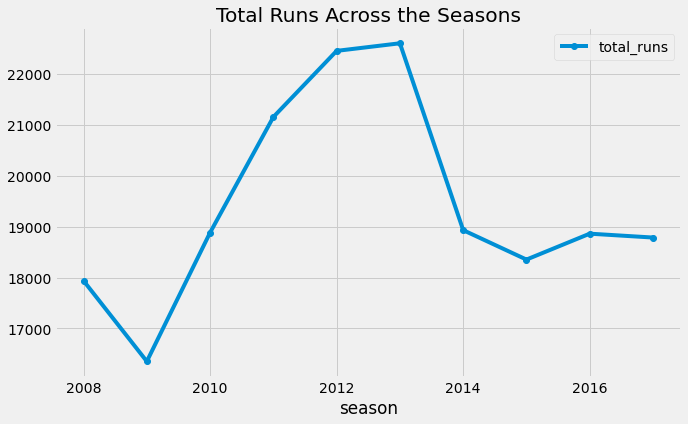

```python
# Creating the batters_df
batters_df = matches[['id','season']].merge(deliveries, left_on = 'id', right_on = 'match_id', how = 'left').drop('id', axis = 1)

# merging the matches and deliveries dataframe by using the id and match_id columns respectively
season_df=batters_df.groupby(['season'])['total_runs'].sum().reset_index()

# creating the plot
season_df.set_index('season').plot(marker='o')
mlt.gcf().set_size_inches(10,6)
mlt.title('Total Runs Across the Seasons')
mlt.show()
```

#### Runs per match across seasons.

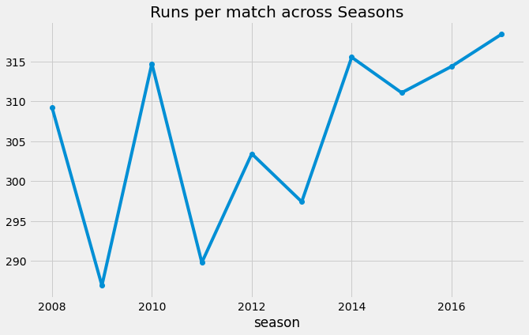

```python
# Creating the avgruns_each_season df
avgruns_each_season=matches.groupby(['season']).count().id.reset_index()
avgruns_each_season.rename(columns={'id':'matches'},inplace=1)
avgruns_each_season['total_runs']=season_df['total_runs']
avgruns_each_season['Runs_per_match']=avgruns_each_season['total_runs']/avgruns_each_season['matches']

# creating the plot.
avgruns_each_season.set_index('season')['Runs_per_match'].plot(marker='o')
mlt.gcf().set_size_inches(10,6)
mlt.title('Runs per match across Seasons')
mlt.show()
```

#### Venue with the most matches!

As we can see, venues in India have the most number of matches!

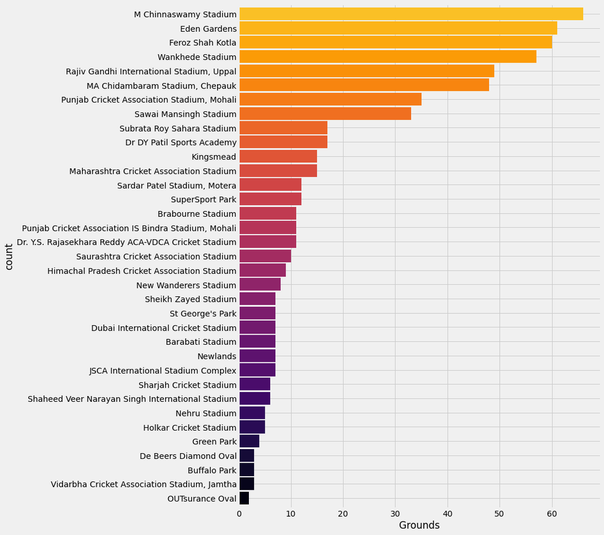

```python
mlt.subplots(figsize=(10,15))
ax = matches['venue'].value_counts().sort_values(ascending=True).plot.barh(width=.9,color=sns.color_palette('inferno',40))
ax.set_xlabel('Grounds')
ax.set_ylabel('count')
mlt.show()
```

#### Score distribution by team by innings

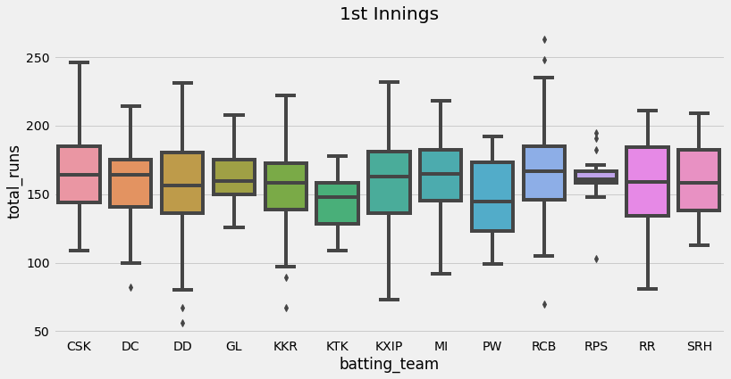

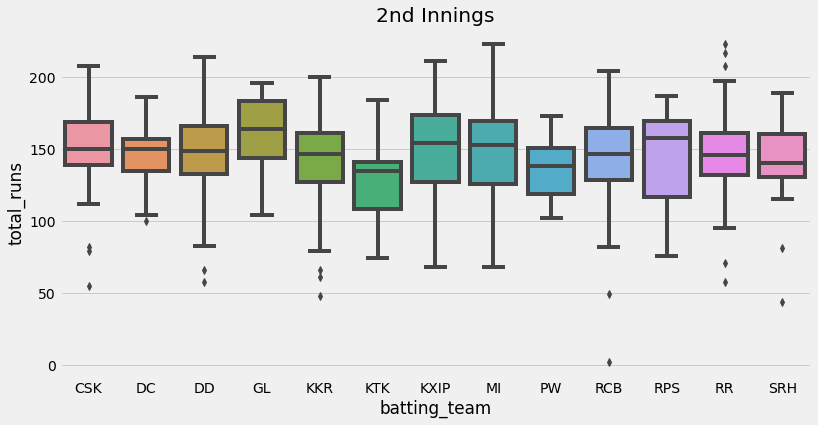

```python
# creating a new df and gathering necessary data.
mlt.subplots(figsize=(12,6))
temp=deliveries.groupby(['match_id','inning','batting_team'])['total_runs'].sum().reset_index()
temp.drop('match_id',axis=1,inplace=True)
temp=temp.sort_values(by=['batting_team','total_runs'],ascending=True)
score_1_inning=temp[temp['inning']==1]
score_2_inning=temp[temp['inning']==2]
sns.boxplot(x='batting_team',y='total_runs',data=score_1_inning).set_title('1st Innings')
mlt.show()
sns.boxplot(x='batting_team',y='total_runs',data=score_2_inning).set_title('2nd Innings')
fig=mlt.gcf()
fig.set_size_inches(12,6)
```

#### Total Matches vs Total Wins for each team

Just to try something new, I used the pyplot library to create an interactive graph the represens the Matchs vs Wins for each team. Only code is provided, this wont render as static html but this will create an interactive graph

```python
# creating DF as needed.
matches_played_byteams=pd.concat([matches['team1'],matches['team2']])
matches_played_byteams=matches_played_byteams.value_counts().reset_index()
matches_played_byteams.columns=['Team','Total Matches']
matches_played_byteams['wins']=matches['winner'].value_counts().reset_index()['winner']
matches_played_byteams.set_index('Team',inplace=True)

trace1 = go.Bar(
    x=matches_played_byteams.index,
    y=matches_played_byteams['wins'],
    name='Matches Won'
)
trace2 = go.Bar(
    x=matches_played_byteams.index,
    y=matches_played_byteams['Total Matches'],
    name='Total Matches'
)

data = [trace1, trace2]
layout = go.Layout(
    barmode='stack'
)

fig = go.Figure(data=data, layout=layout)
py.iplot(fig, filename='stacked-bar')
```

### Conclusion

We've seen a lot of different statistics, alot of ways of visualizing these satatistcs and important observations when it comes to handling data. For some of you reading this, it could your first time reading about, understanding and analyzing cricket. Here are few important takeaways and observations (in terms of Data Science and Cricket):

The one important thing about Data Science that we need to talk about is that correlation does not neccessarily mean causation (it might seem trivial but good to be explicit at times). It is also important to know and understand your data. This will let us handle it well, tidy it and use it efficienlty. As we've seen graphs can sometimes convey the wrong message. For the graph that we showed the number of times a team wins the toss, the graph plainly indicates that some teams win a lot and som teams did not win a lot, It does not take into account how many games each team played. Some teams might have played a lot of games while others not that many, but that graph does not say that!. So, if possible, we should always standardize data! In or example, we could have calculated the same over the number of games each of those teams played.  
If you like what you see and are interested to learn more, good knews! Data Science is an amazing open field! You can find resouces and amazing documentation for concepts and tools I've used here! A few are listed below:

- Pandas Documentation:https://pandas.pydata.org/docs/
- Matplotlib Documentaion: https://matplotlib.org/stable/contents.html
- Seaborn Documentation: https://seaborn.pydata.org/
- Data Processing: = https://medium.com/better-programming/data-engineering-101-from-batch-processing-to-streaming-54f8c0da66fb
- Exploratory Data Analysis: https://towardsdatascience.com/exploratory-data-analysis-eda-a-practical-guide-and-template-for-structured-data-abfbf3ee3bd9 </ul> Thank you for your time, I hope this kindled your interest in Data Science and Cricket. Making this definitly made feel closer to home.